# 6306 Case Study 2 -

### Attrition vs. Total Working Years

#### Attrition decreases with Total Working Years and this also may be related to age.

| TotalWorkingYearsby5 | Attrition | Freq |
| --- | --- | --- |
| 0-4 | No | 0.1040816 |
| 5-9 | No | 0.2795918 |
| 10-14 | No | 0.3061224 |
| 15-19 | No | 0.0782313 |
| 20-24 | No | 0.0380952 |
| 25-29 | No | 0.0231293 |
| 30-34 | No | 0.0095238 |
| 35-40 | No | 0.0000000 |
| 0-4 | Yes | 0.0510204 |
| 5-9 | Yes | 0.0557823 |
| 10-14 | Yes | 0.0421769 |
| 15-19 | Yes | 0.0068027 |
| 20-24 | Yes | 0.0020408 |
| 25-29 | Yes | 0.0020408 |
| 30-34 | Yes | 0.0000000 |
| 35-40 | Yes | 0.0013605 |

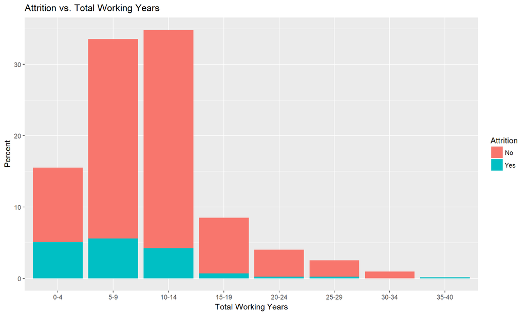

### Attrition vs. Training Times Last Year

#### Training Times Last Year does not seem to correlate with attrition.

| TrainingTimesLastYear | Attrition | Freq |
| --- | --- | --- |
| 0 | No | 0.0265306 |
| 1 | No | 0.0421769 |
| 2 | No | 0.3054422 |
| 3 | No | 0.2870748 |
| 4 | No | 0.0659864 |
| 5 | No | 0.0714286 |
| 6 | No | 0.0401361 |
| 0 | Yes | 0.0102041 |
| 1 | Yes | 0.0061224 |
| 2 | Yes | 0.0666667 |
| 3 | Yes | 0.0469388 |
| 4 | Yes | 0.0176871 |
| 5 | Yes | 0.0095238 |
| 6 | Yes | 0.0040816 |

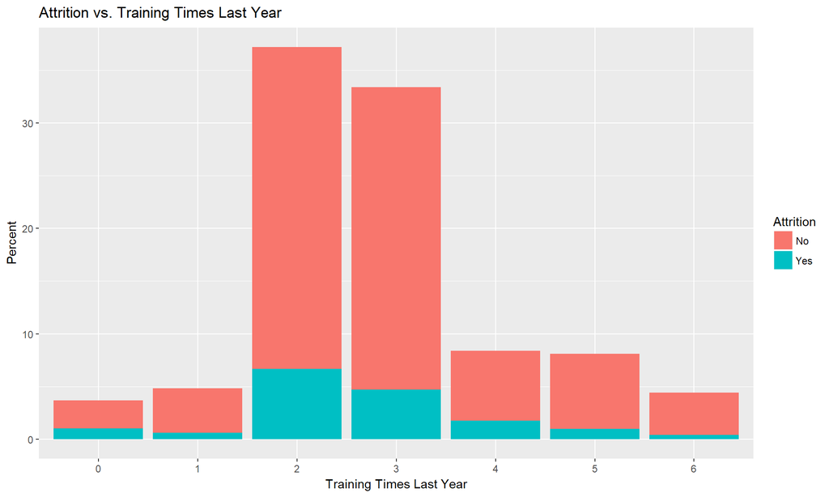

### Attrition vs. Work Life Balance

#### Poor Work Life Balance seem to have some influence on increased attrition.

| WorkLifeBalance | Attrition | Freq |
| --- | --- | --- |
| 1 | No | 0.0374150 |
| 2 | No | 0.1945578 |
| 3 | No | 0.5210884 |
| 4 | No | 0.0857143 |
| 1 | Yes | 0.0170068 |
| 2 | Yes | 0.0394558 |
| 3 | Yes | 0.0863946 |
| 4 | Yes | 0.0183673 |

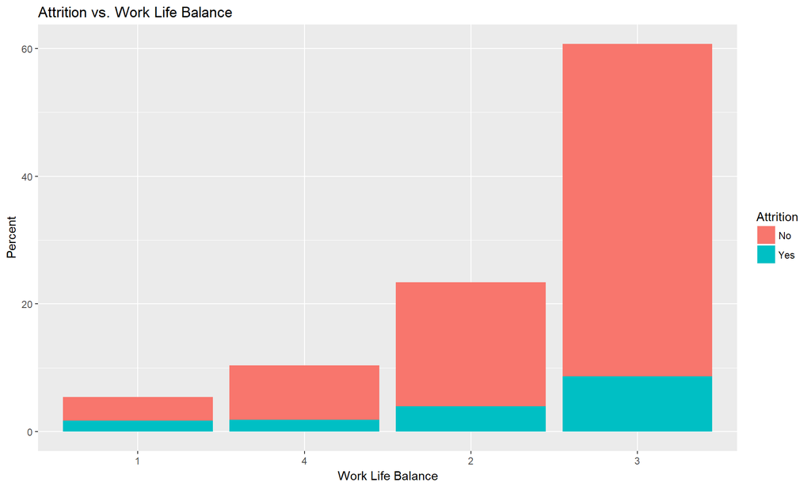

### Attrition vs. Years At Company

#### Attrition decreases with Years At Company and this too may be related to age.

| YearsAtCompanyby5 | Attrition | Freq |
| --- | --- | --- |
| 0-04 | No | 0.2986395 |
| 05-09 | No | 0.3170068 |
| 10-14 | No | 0.1251701 |
| 15-19 | No | 0.0408163 |
| 20-24 | No | 0.0401361 |
| 25-29 | No | 0.0081633 |
| 30-34 | No | 0.0068027 |
| 35-40 | No | 0.0020408 |
| 0-04 | Yes | 0.0959184 |
| 05-09 | Yes | 0.0394558 |
| 10-14 | Yes | 0.0163265 |
| 15-19 | Yes | 0.0034014 |
| 20-24 | Yes | 0.0034014 |
| 25-29 | Yes | 0.0000000 |
| 30-34 | Yes | 0.0020408 |
| 35-40 | Yes | 0.0006803 |

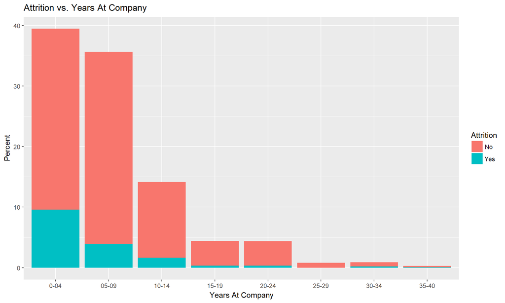

### Attrition vs. Years In Current Role

#### Attrition decreases with Years In Current Role and this could be related to age.

| YearsInCurrentRole | Attrition | Freq |
| --- | --- | --- |
| 0 | No | 0.1163265 |
| 1 | No | 0.0312925 |
| 2 | No | 0.2068027 |
| 3 | No | 0.0809524 |
| 4 | No | 0.0605442 |
| 5 | No | 0.0238095 |
| 6 | No | 0.0238095 |
| 7 | No | 0.1299320 |
| 8 | No | 0.0557823 |
| 9 | No | 0.0414966 |
| 10 | No | 0.0183673 |
| 11 | No | 0.0149660 |
| 12 | No | 0.0061224 |
| 13 | No | 0.0088435 |
| 14 | No | 0.0068027 |
| 15 | No | 0.0040816 |
| 16 | No | 0.0047619 |
| 17 | No | 0.0027211 |
| 18 | No | 0.0013605 |
| 0 | Yes | 0.0496599 |
| 1 | Yes | 0.0074830 |
| 2 | Yes | 0.0462585 |
| 3 | Yes | 0.0108844 |
| 4 | Yes | 0.0102041 |
| 5 | Yes | 0.0006803 |
| 6 | Yes | 0.0013605 |
| 7 | Yes | 0.0210884 |
| 8 | Yes | 0.0047619 |
| 9 | Yes | 0.0040816 |
| 10 | Yes | 0.0013605 |
| 11 | Yes | 0.0000000 |
| 12 | Yes | 0.0006803 |
| 13 | Yes | 0.0006803 |
| 14 | Yes | 0.0006803 |
| 15 | Yes | 0.0013605 |
| 16 | Yes | 0.0000000 |
| 17 | Yes | 0.0000000 |
| 18 | Yes | 0.0000000 |

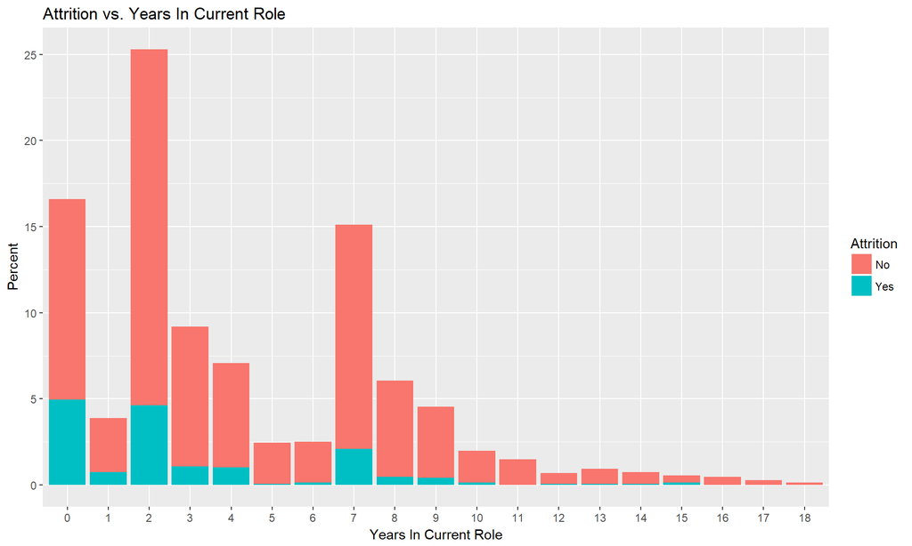

### Attrition vs. Years Since Last Promotion

#### Years Since Last Promotion seems to have little influence on attrition.

| YearsSinceLastPromotion | Attrition | Freq |
| --- | --- | --- |
| 0 | No | 0.3204082 |
| 1 | No | 0.2095238 |
| 2 | No | 0.0897959 |
| 3 | No | 0.0292517 |
| 4 | No | 0.0380952 |
| 5 | No | 0.0292517 |
| 6 | No | 0.0176871 |
| 7 | No | 0.0408163 |
| 8 | No | 0.0122449 |
| 9 | No | 0.0088435 |
| 10 | No | 0.0034014 |
| 11 | No | 0.0149660 |
| 12 | No | 0.0068027 |
| 13 | No | 0.0054422 |
| 14 | No | 0.0054422 |
| 15 | No | 0.0068027 |
| 0 | Yes | 0.0748299 |
| 1 | Yes | 0.0333333 |
| 2 | Yes | 0.0183673 |
| 3 | Yes | 0.0061224 |
| 4 | Yes | 0.0034014 |
| 5 | Yes | 0.0013605 |
| 6 | Yes | 0.0040816 |
| 7 | Yes | 0.0108844 |
| 8 | Yes | 0.0000000 |
| 9 | Yes | 0.0027211 |
| 10 | Yes | 0.0006803 |
| 11 | Yes | 0.0013605 |
| 12 | Yes | 0.0000000 |
| 13 | Yes | 0.0013605 |
| 14 | Yes | 0.0006803 |
| 15 | Yes | 0.0020408 |

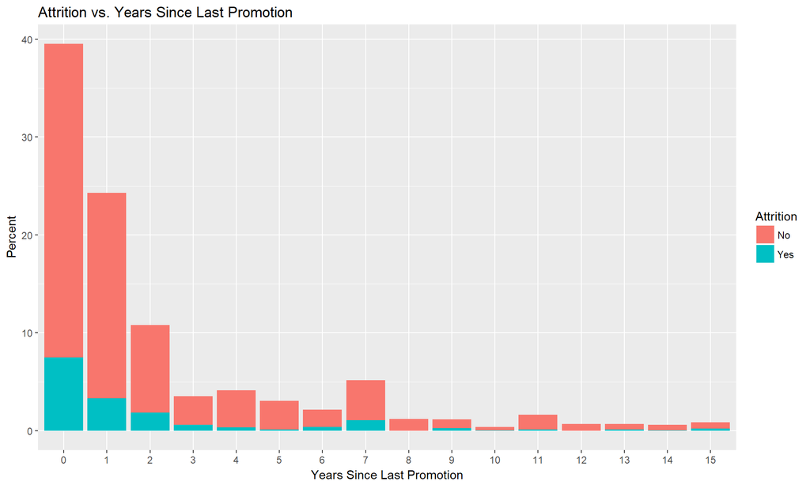

### Attrition vs. Years With Current Manager

#### Years With Current Manager seems to have little influence on attrition beyond the first year.

| YearsWithCurrManager | Attrition | Freq |
| --- | --- | --- |
| 0 | No | 0.1210884 |
| 1 | No | 0.0442177 |
| 2 | No | 0.2000000 |
| 3 | No | 0.0836735 |
| 4 | No | 0.0591837 |
| 5 | No | 0.0183673 |
| 6 | No | 0.0170068 |
| 7 | No | 0.1258503 |
| 8 | No | 0.0659864 |
| 9 | No | 0.0394558 |
| 10 | No | 0.0163265 |
| 11 | No | 0.0142857 |
| 12 | No | 0.0122449 |
| 13 | No | 0.0095238 |
| 14 | No | 0.0020408 |
| 15 | No | 0.0034014 |
| 16 | No | 0.0013605 |
| 17 | No | 0.0047619 |
| 0 | Yes | 0.0578231 |
| 1 | Yes | 0.0074830 |
| 2 | Yes | 0.0340136 |
| 3 | Yes | 0.0129252 |
| 4 | Yes | 0.0074830 |
| 5 | Yes | 0.0027211 |
| 6 | Yes | 0.0027211 |
| 7 | Yes | 0.0210884 |
| 8 | Yes | 0.0068027 |
| 9 | Yes | 0.0040816 |
| 10 | Yes | 0.0020408 |
| 11 | Yes | 0.0006803 |
| 12 | Yes | 0.0000000 |
| 13 | Yes | 0.0000000 |
| 14 | Yes | 0.0013605 |
| 15 | Yes | 0.0000000 |
| 16 | Yes | 0.0000000 |
| 17 | Yes | 0.0000000 |

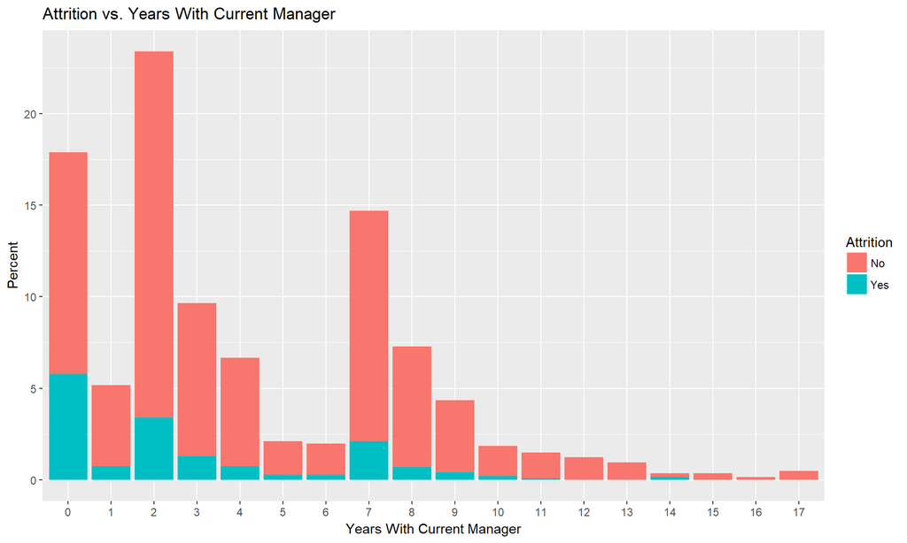

### Attrition vs. Monthly income

#### Lower income groups appear to show a significant correlation in turnover for lower income individuals

| MonthlyIncomeBy1000 | Attrition | Freq |
| --- | --- | --- |
| 2000 | No | 0.0102041 |
| 3000 | No | 0.1816327 |
| 4000 | No | 0.0836735 |
| 5000 | No | 0.1231293 |
| 6000 | No | 0.1013605 |
| 7000 | No | 0.0748299 |
| 8000 | No | 0.0319728 |
| 9000 | No | 0.0285714 |
| 10000 | No | 0.0292517 |
| 11000 | No | 0.0360544 |
| 12000 | No | 0.0129252 |
| 13000 | No | 0.0054422 |
| 14000 | No | 0.0265306 |
| 15000 | No | 0.0061224 |
| 16000 | No | 0.0047619 |
| 17000 | No | 0.0197279 |
| 18000 | No | 0.0190476 |
| 19000 | No | 0.0122449 |
| 20000 | No | 0.0312925 |
| 2000 | Yes | 0.0122449 |
| 3000 | Yes | 0.0646259 |
| 4000 | Yes | 0.0163265 |
| 5000 | Yes | 0.0176871 |
| 6000 | Yes | 0.0108844 |
| 7000 | Yes | 0.0074830 |
| 8000 | Yes | 0.0047619 |
| 9000 | Yes | 0.0040816 |
| 10000 | Yes | 0.0061224 |
| 11000 | Yes | 0.0088435 |
| 12000 | Yes | 0.0006803 |
| 13000 | Yes | 0.0013605 |
| 14000 | Yes | 0.0027211 |
| 15000 | Yes | 0.0000000 |
| 16000 | Yes | 0.0000000 |
| 17000 | Yes | 0.0000000 |
| 18000 | Yes | 0.0000000 |
| 19000 | Yes | 0.0006803 |
| 20000 | Yes | 0.0027211 |

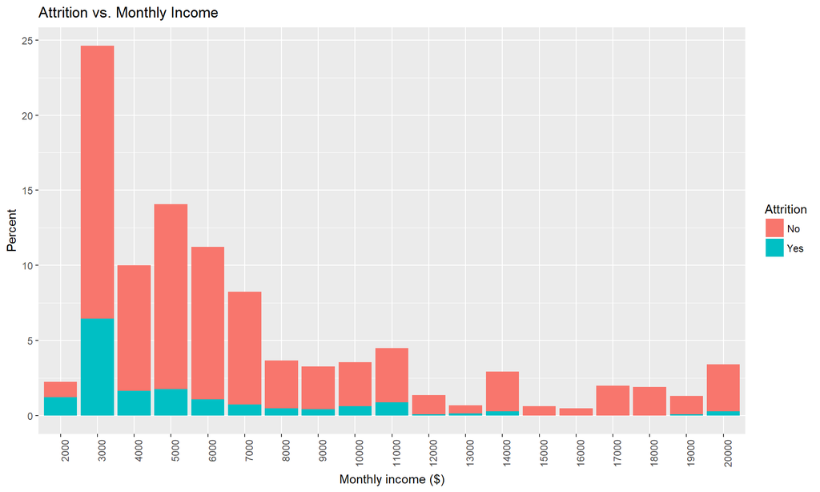